# Flexibility, Regression, Simulated Data

Hajin Jang

9/23/2025

# Concepts

#### a. The sample size n is extremely large, and the number of predictors p is small.

*Flexible method > Inflexible method*

Flexible methods can leverage large datasets to model complex relationships between predictors and outcomes without overfitting. With sufficient sample size, the risk of overfitting, often associated with highly flexible model, is minimized. Moreover, these methods are better equipped to detect subtle or intricate patterns in the data that less flexible approaches may overlook.

#### b. The number of predictors p is extremely large, and the number of observations n is small.

*Inflexible method > Flexible method*

Here, flexible methods are at greater risk of overfitting. In contrast, inflexible methods, which enforce stronger structure and rely on fewer assumptions about the data, are less likely to overfit and can yield more dependable predictions when the dataset is small compared to the number of predictors.

#### c. The relationship between the predictors and response is highly non-linear.

*Flexible method > Inflexible method*

Flexible methods are designed to model complex, non-linear connections between predictors and the outcome. In contrast, inflexible approaches like linear regression rely on predetermined functional forms and may fail to represent the data accurately when the underlying relationships are strongly non-linear.

#### d. The variance of the error terms, i.e. σ2 = Var(ϵ), is extremely high.

*Inflexible method > Flexible method*

In this scenario, the data is highly noisy. Flexible methods often overfit by attempting to capture this noise, which harms their ability to generalize. In contrast, inflexible methods, by enforcing stronger structure and being less reactive to random variation, typically perform better, as they are less prone to fitting the noise.

# Standard regression model

```r
library(ISLR2)
head(Carseats)
```

```
##   Sales CompPrice Income Advertising Population Price ShelveLoc Age Education
## 1  9.50       138     73          11        276   120       Bad  42        17
## 2 11.22       111     48          16        260    83      Good  65        10
## 3 10.06       113     35          10        269    80    Medium  59        12
## 4  7.40       117    100           4        466    97    Medium  55        14
## 5  4.15       141     64           3        340   128       Bad  38        13
## 6 10.81       124    113          13        501    72       Bad  78        16
##   Urban  US
## 1   Yes Yes
## 2   Yes Yes
## 3   Yes Yes
## 4   Yes Yes
## 5   Yes  No
## 6    No Yes
```

#### Fitting a multiple regression model

```r
lm.fit <- lm(Sales ~ Price + Urban + US, data=Carseats)
summary(lm.fit)
```

```
##
## Call:
## lm(formula = Sales ~ Price + Urban + US, data = Carseats)
##
## Residuals:
##     Min      1Q  Median      3Q     Max
## -6.9206 -1.6220 -0.0564  1.5786  7.0581
##
## Coefficients:
##              Estimate Std. Error t value Pr(>|t|)
## (Intercept) 13.043469   0.651012  20.036  < 2e-16 ***
## Price       -0.054459   0.005242 -10.389  < 2e-16 ***
## UrbanYes    -0.021916   0.271650  -0.081    0.936
## USYes        1.200573   0.259042   4.635 4.86e-06 ***
## ---
## Signif. codes:  0 '***' 0.001 '**' 0.01 '*' 0.05 '.' 0.1 ' ' 1
##
## Residual standard error: 2.472 on 396 degrees of freedom
## Multiple R-squared:  0.2393, Adjusted R-squared:  0.2335
## F-statistic: 41.52 on 3 and 396 DF,  p-value: < 2.2e-16
```

#### Interpretation

1. Intercept: For a product sold outside the US and in a non-urban setting, the expected sales are 13.04 thousand dollars when the price is zero.
2. Price: For every increase of $1 in the price of the carseat, the sales are expected to decrease by $0.0545K, or $54.50, holding the Urban and US variables constant. This effect is statistically significant (p-value<2e-16).
3. Urban: The expected sales in an urban setting are $21.92 lower than in a non-urban setting, holding the price and US status constant. This effect is not statistically significant (p-value = 0.94), so we cannot conclude that the urban setting has a meaningful impact on sales.
4. US: The sales in the US are expected to be $1.2K (or $1,200) higher than in non-US regions, holding the price and urban status constant. This effect is statistically significant (p-value=4.86e-06).

#### Model equation

$$Sales = 13.04 - 0.054*Price - 0.022*(Urban Yes=1) + 1.2*(US Yes=1)+𝝐$$

#### Hypothesis testing

Price and US, since their p-values are below 0.05, allowing us to reject the null hypothesis for these predictors.

#### Smaller model

```r
lm.fit2 <- lm(Sales ~ Price + US, data=Carseats)
summary(lm.fit2)
```

```
##
## Call:
## lm(formula = Sales ~ Price + US, data = Carseats)
##
## Residuals:
##     Min      1Q  Median      3Q     Max
## -6.9269 -1.6286 -0.0574  1.5766  7.0515
##
## Coefficients:
##             Estimate Std. Error t value Pr(>|t|)
## (Intercept) 13.03079    0.63098  20.652  < 2e-16 ***
## Price       -0.05448    0.00523 -10.416  < 2e-16 ***
## USYes        1.19964    0.25846   4.641 4.71e-06 ***
## ---
## Signif. codes:  0 '***' 0.001 '**' 0.01 '*' 0.05 '.' 0.1 ' ' 1
##
## Residual standard error: 2.469 on 397 degrees of freedom
## Multiple R-squared:  0.2393, Adjusted R-squared:  0.2354
## F-statistic: 62.43 on 2 and 397 DF,  p-value: < 2.2e-16
```

#### Model comparison

```r
anova(lm.fit2, lm.fit)
```

```
## Analysis of Variance Table
##
## Model 1: Sales ~ Price + US
## Model 2: Sales ~ Price + Urban + US
##   Res.Df    RSS Df Sum of Sq      F Pr(>F)
## 1    397 2420.9
## 2    396 2420.8  1   0.03979 0.0065 0.9357
```

**Comment:** The ANOVA test indicates that the simpler Model (e) is adequate.

#### 95% CI

```r
coef(lm.fit2)
```

```
## (Intercept)       Price       USYes
## 13.03079275 -0.05447763  1.19964294
```

```r
confint(lm.fit2)
```

```
##                   2.5 %      97.5 %
## (Intercept) 11.79032020 14.27126531
## Price       -0.06475984 -0.04419543
## USYes        0.69151957  1.70776632
```

**Comment:** Intercept: (11.79, 14.27) Price: (-0.06, -0.04) US Yes: (0.69, 1.71)

#### Outliers or high leverage observations

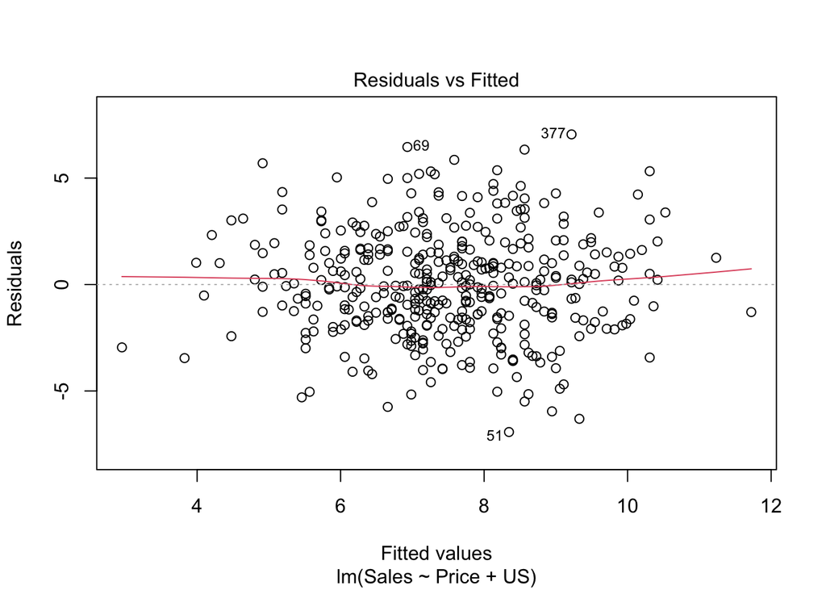

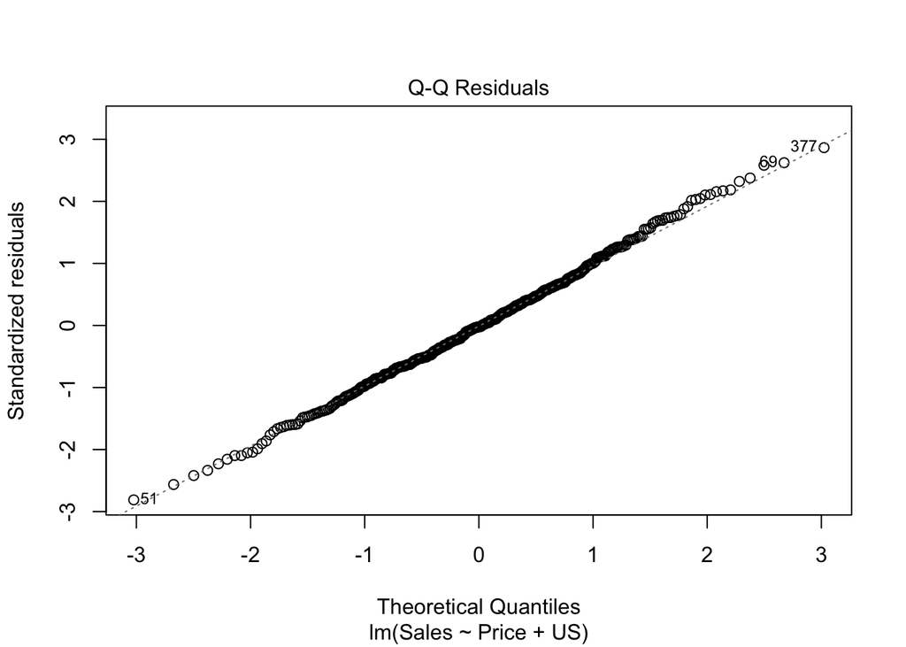

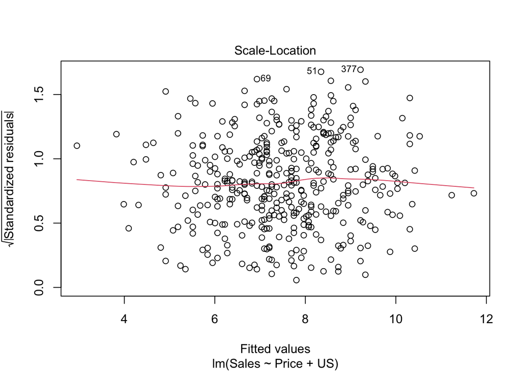

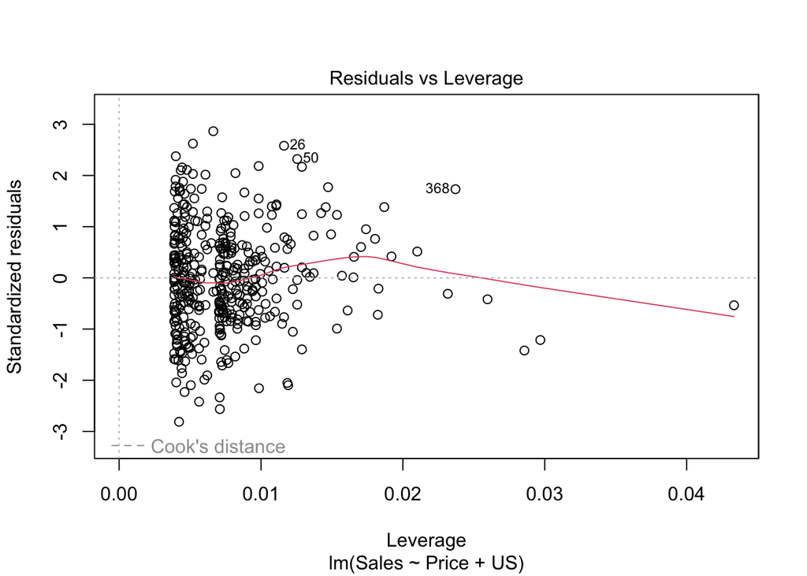

```r
plot(lm.fit2)
```

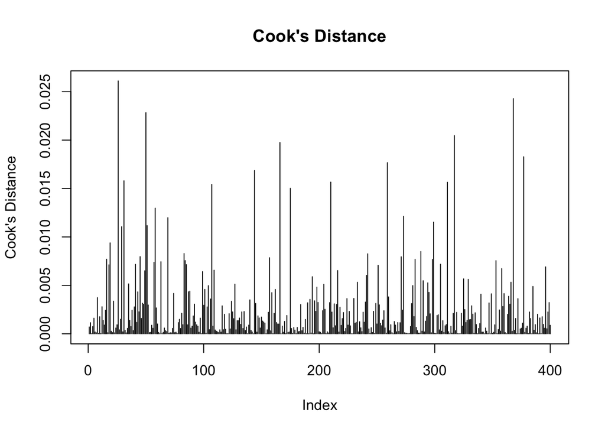

```r
cook_dist <- cooks.distance(lm.fit2)
plot(cook_dist, type="h", main="Cook's Distance", ylab="Cook's Distance")
abline(h = 0.5, col="red")
```

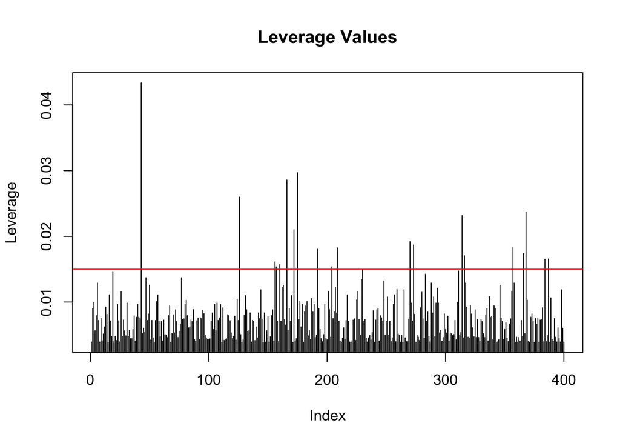

```r
hat_values <- hatvalues(lm.fit2)
plot(hat_values, type="h", main="Leverage Values", ylab="Leverage")
abline(h = 2 * (length(coef(lm.fit2)) / nrow(Carseats)), col="red")
```

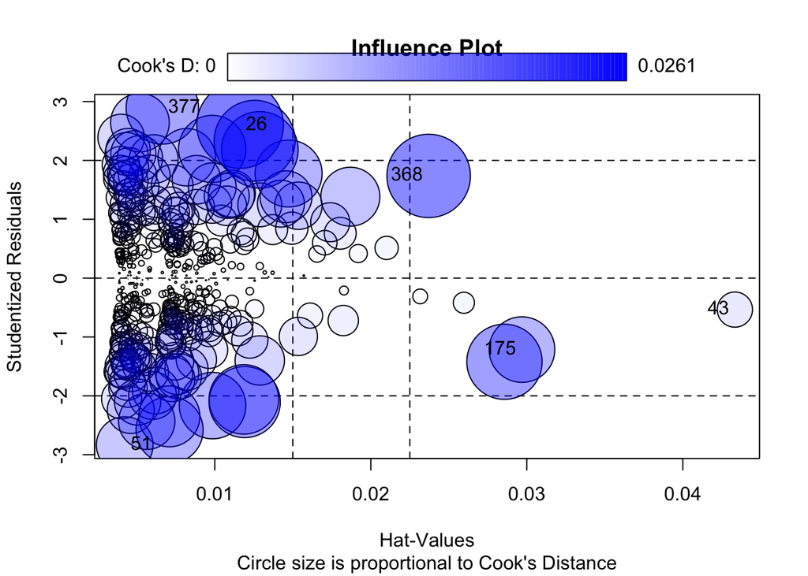

```
##        StudRes         Hat       CookD
## 26   2.5996518 0.011621599 0.026109457
## 43  -0.5349931 0.043337657 0.004329756
## 51  -2.8358431 0.004224147 0.011173381
## 175 -1.2144859 0.029686718 0.015024314
## 368  1.7366086 0.023707048 0.024287363
## 377  2.8915213 0.006637175 0.018282191
```

```r
library(car)
influencePlot(lm.fit2, id.method="identify", main="Influence Plot", sub="Circle size is proportional to Cook's Distance")
```

**Comment:** Observations 26 and 368 appear in both the Residuals vs. Leverage plot and the Influence plot, suggesting they may exert both high leverage and strong influence on the model. Likewise, observation 377 shows up in both the QQ plot and the Influence plot, indicating it could also be an outlier.

# Creating and using simulated data

#### Vector x

```r
set.seed(1)
x <- rnorm(100, mean=0, sd=1)
head(x)
```

```
## [1] -0.6264538  0.1836433 -0.8356286  1.5952808  0.3295078 -0.8204684
```

#### Vector eps

```r
set.seed(2)
eps <- rnorm(100, mean=0, sd=sqrt(0.25))
head(eps)
```

```
## [1] -0.44845727  0.09242459  0.79392267 -0.56518784 -0.04012588  0.06621014
```

#### Vector Y = −1+0.5X + ϵ

```r
y <- -1 + 0.5*x + eps
length(y)
```

```
## [1] 100
```

```r
head(y)
```

```
## [1] -1.7616842 -0.8157537 -0.6238916 -0.7675474 -0.8753720 -1.3440240
```

**Comment:** The vector y has a length of 100. β0 is the intercept with a value of -1. β1 is the coefficient for x and has a value of 0.5.

#### Scatter plot

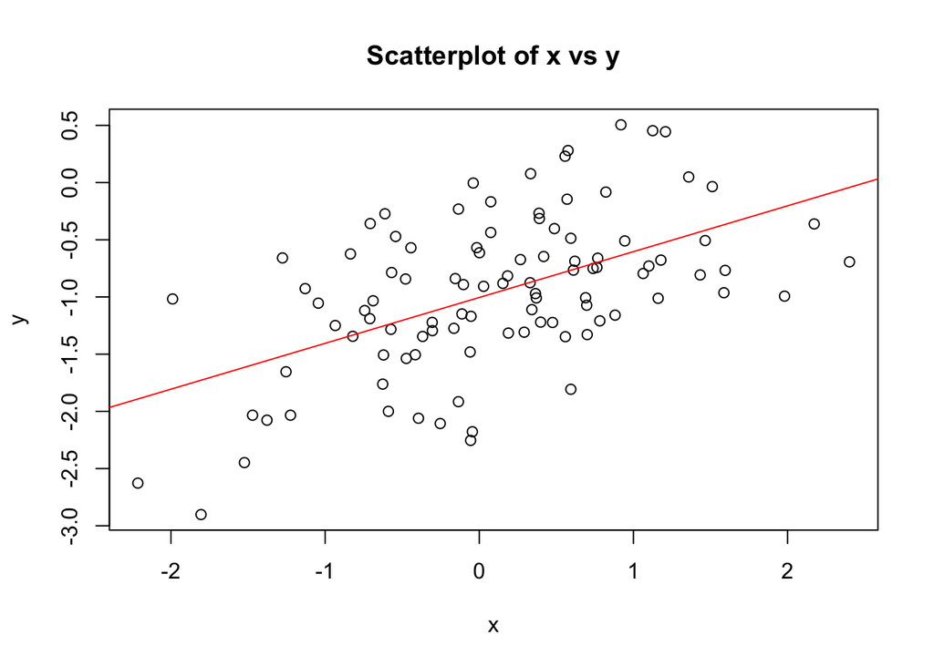

```r
plot(x, y, main = "Scatterplot of x vs y", xlab = "x", ylab = "y")
abline(lm(y ~ x), col = "red", lwd = 1)
```

**Comment:** The scatterplot indicates a positive linear relationship between x and y. The variability around the line comes from the random error term ϵ, which has a variance of 0.25.

#### Least squares linear model to predict y using x

```r
model <- lm(y ~ x)
summary(model)
```

```
##
## Call:
## lm(formula = y ~ x)
##
## Residuals:
##      Min       1Q   Median       3Q      Max
## -1.22689 -0.40393 -0.04575  0.41574  1.14118
##
## Coefficients:
##             Estimate Std. Error t value Pr(>|t|)
## (Intercept) -1.00454    0.05804 -17.308  < 2e-16 ***
## x            0.40072    0.06446   6.216 1.25e-08 ***
## ---
## Signif. codes:  0 '***' 0.001 '**' 0.01 '*' 0.05 '.' 0.1 ' ' 1
##
## Residual standard error: 0.5761 on 98 degrees of freedom
## Multiple R-squared:  0.2828, Adjusted R-squared:  0.2755
## F-statistic: 38.64 on 1 and 98 DF,  p-value: 1.247e-08
```

**Comment:** The fitted model is
$$y=-1.00454+0.40072x$$

β0 is -1, β^0 is -1.00454. β1 is 0.5, β^1 is 0.40072.

The estimated intercept βˆ0 is very close to the true value β0=−1, while βˆ1=0.40072 differs somewhat from the true value β1=0.5, which is reasonable given the noise introduced by ϵ. Overall, the model provides a good fit, accounting for 27.6% of the variation in y.

#### Display the plots

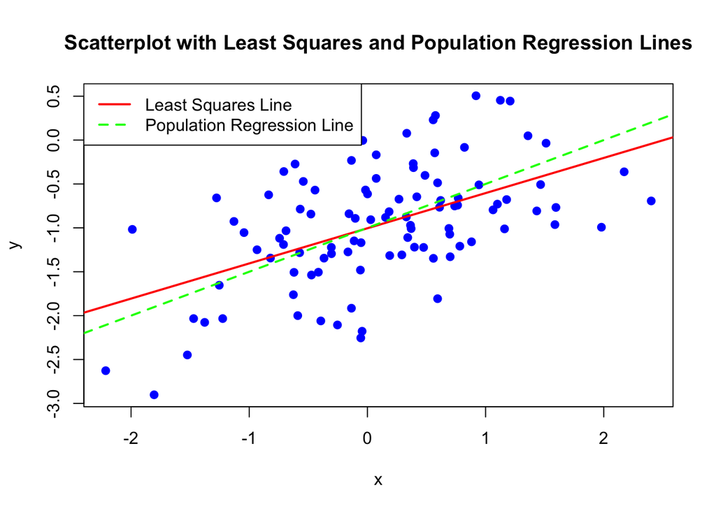

```r
plot(x, y, main = "Scatterplot with Least Squares and Population Regression Lines",      xlab = "x", ylab = "y", pch = 19, col = "blue")
abline(lm(y ~ x), col = "red", lwd = 2)
abline(a = -1, b = 0.5, col = "green", lwd = 2, lty = 2)
legend("topleft", legend = c("Least Squares Line", "Population Regression Line"),
       col = c("red", "green"), lty = c(1, 2), lwd = 2)
```

#### Polynomial regression model

```r
model2 <- lm(y ~ x + I(x^2))
summary(model2)
```

```
##
## Call:
## lm(formula = y ~ x + I(x^2))
##
## Residuals:
##      Min       1Q   Median       3Q      Max
## -1.30604 -0.38957 -0.06695  0.40921  1.13539
##
## Coefficients:
##             Estimate Std. Error t value Pr(>|t|)
## (Intercept) -0.92420    0.06967 -13.265  < 2e-16 ***
## x            0.41623    0.06394   6.509 3.33e-09 ***
## I(x^2)      -0.10121    0.05020  -2.016   0.0465 *
## ---
## Signif. codes:  0 '***' 0.001 '**' 0.01 '*' 0.05 '.' 0.1 ' ' 1
##
## Residual standard error: 0.5673 on 97 degrees of freedom
## Multiple R-squared:  0.3116, Adjusted R-squared:  0.2974
## F-statistic: 21.96 on 2 and 97 DF,  p-value: 1.362e-08
```

The p-value for x^2 is below 0.05, indicating that the quadratic term makes a significant contribution to the model. The Adjusted R-squared has increased to 29.74%, showing improvement over the previous model.

```r
anova(model, model2)
```

```
## Analysis of Variance Table
##
## Model 1: y ~ x
## Model 2: y ~ x + I(x^2)
##   Res.Df    RSS Df Sum of Sq      F  Pr(>F)
## 1     98 32.527
## 2     97 31.219  1    1.3083 4.0652 0.04654 *
## ---
## Signif. codes:  0 '***' 0.001 '**' 0.01 '*' 0.05 '.' 0.1 ' ' 1
```

The results suggest that including the quadratic term enhances the model, and a quadratic regression may provide a better fit.

#### Reducing noise

```r
set.seed(1)
x2 <- rnorm(100, mean = 0, sd = 1)
```

```r
set.seed(2)
eps2 <- rnorm(100, mean = 0, sd = sqrt(0.01))
```

```r
y2 <- -1 + 0.5 * x2 + eps2
```

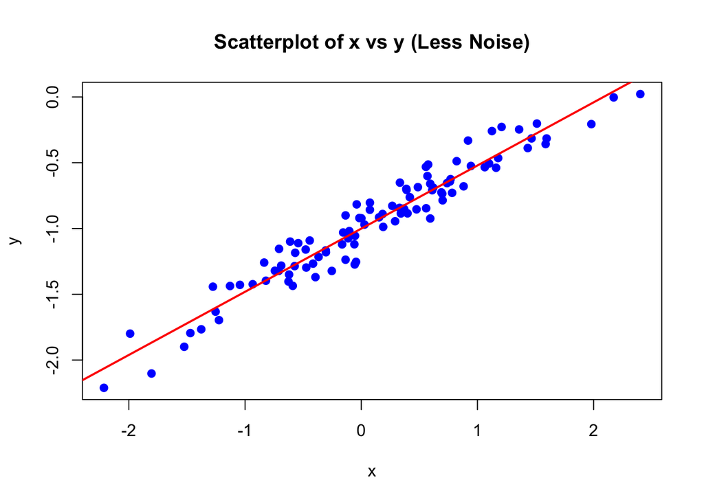

```r
plot(x2, y2, main = "Scatterplot of x vs y (Less Noise)", xlab = "x", ylab = "y", pch = 19, col = "blue")
abline(lm(y2 ~ x2), col = "red", lwd = 2)
```

The scatterplot shows that the points are now clustered more closely around the regression line than before, indicating less noise in the data.

```r
model2 <- lm(y2 ~ x2)
summary(model2)
```

```
##
## Call:
## lm(formula = y2 ~ x2)
##
## Residuals:
##      Min       1Q   Median       3Q      Max
## -0.24538 -0.08078 -0.00915  0.08315  0.22824
##
## Coefficients:
##             Estimate Std. Error t value Pr(>|t|)
## (Intercept) -1.00091    0.01161  -86.23   <2e-16 ***
## x2           0.48014    0.01289   37.24   <2e-16 ***
## ---
## Signif. codes:  0 '***' 0.001 '**' 0.01 '*' 0.05 '.' 0.1 ' ' 1
##
## Residual standard error: 0.1152 on 98 degrees of freedom
## Multiple R-squared:  0.934,  Adjusted R-squared:  0.9333
## F-statistic:  1387 on 1 and 98 DF,  p-value: < 2.2e-16
```

The estimated coefficients β^0=-1.00091 and β^1=0.48014 are closer to the true values (β0=-1 and β1=0.5) than in the first model, due to reduced noise variation. The Adjusted R-squared has risen to 93.33%, showing that this model accounts for 93.33% of the variance in y, a substantial improvement over the first model.

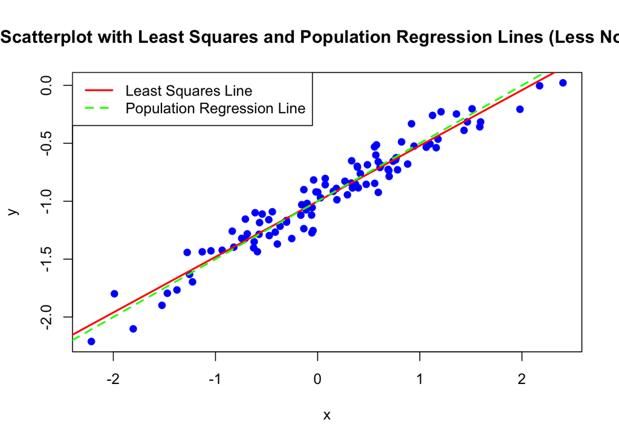

```r
plot(x2, y2, main = "Scatterplot with Least Squares and Population Regression Lines (Less Noise)",
     xlab = "x", ylab = "y", pch = 19, col = "blue")
abline(lm(y2 ~ x2), col = "red", lwd = 2)
abline(a = -1, b = 0.5, col = "green", lwd = 2, lty = 2)
legend("topleft", legend = c("Least Squares Line", "Population Regression Line"),
       col = c("red", "green"), lty = c(1, 2), lwd = 2)
```

With the lower variability in the residuals, the least squares line closely aligns with the true population regression line.

#### Increasing noise

```r
set.seed(1)
x3 <- rnorm(100, mean = 0, sd = 1)
```

```r
set.seed(2)
eps3 <- rnorm(100, mean = 0, sd = sqrt(4))
```

```r
y3 <- -1 + 0.5 * x3 + eps3
```

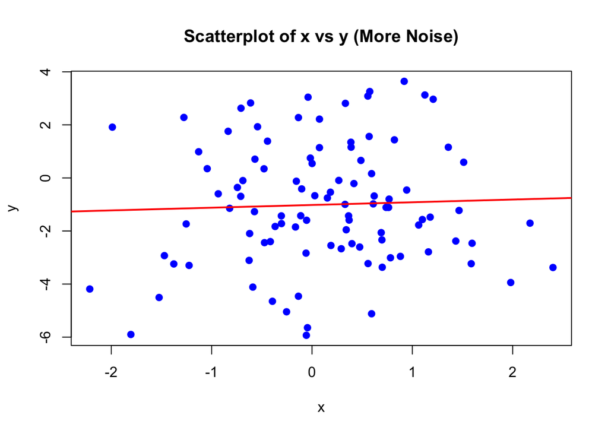

```r
plot(x3, y3, main = "Scatterplot of x vs y (More Noise)", xlab = "x", ylab = "y", pch = 19, col = "blue")
abline(lm(y3 ~ x3), col = "red", lwd = 2)
```

```r
model3 <- lm(y3 ~ x3)
summary(model3)
```

```
##
## Call:
## lm(formula = y3 ~ x3)
##
## Residuals:
##    Min     1Q Median     3Q    Max
## -4.907 -1.616 -0.183  1.663  4.565
##
## Coefficients:
##             Estimate Std. Error t value Pr(>|t|)
## (Intercept)  -1.0182     0.2322  -4.386 2.91e-05 ***
## x3            0.1029     0.2579   0.399    0.691
## ---
## Signif. codes:  0 '***' 0.001 '**' 0.01 '*' 0.05 '.' 0.1 ' ' 1
##
## Residual standard error: 2.304 on 98 degrees of freedom
## Multiple R-squared:  0.001622,   Adjusted R-squared:  -0.008566
## F-statistic: 0.1592 on 1 and 98 DF,  p-value: 0.6908
```

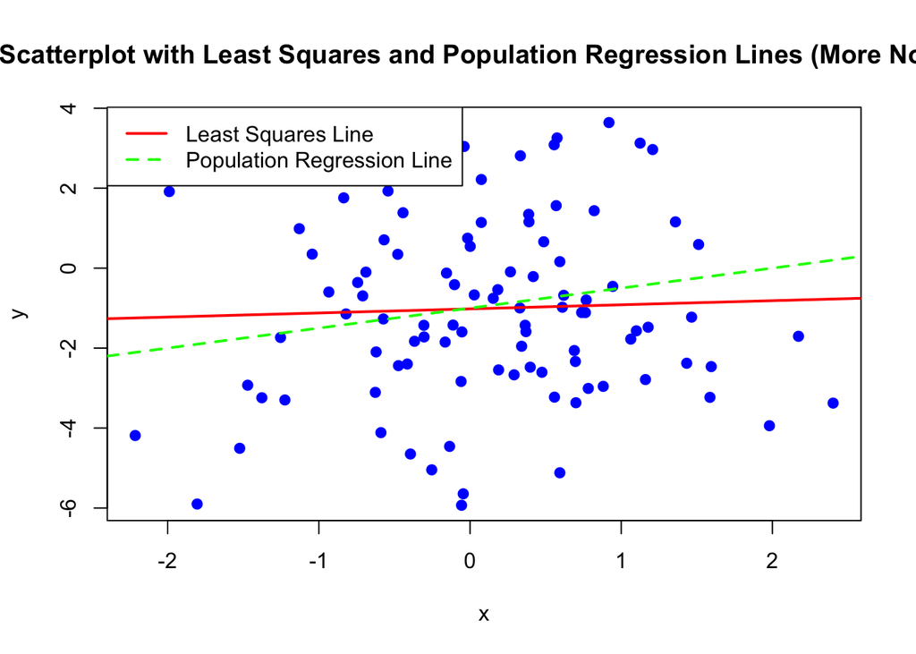

```r
plot(x3, y3, main = "Scatterplot with Least Squares and Population Regression Lines (More Noise)",
     xlab = "x", ylab = "y", pch = 19, col = "blue")
abline(lm(y3 ~ x3), col = "red", lwd = 2)
abline(a = -1, b = 0.5, col = "green", lwd = 2, lty = 2)
legend("topleft", legend = c("Least Squares Line", "Population Regression Line"),
       col = c("red", "green"), lty = c(1, 2), lwd = 2)
```

When noise increases, the model fits less effectively, and the data points are dispersed more broadly around the regression line.

#### 95% CI

```r
# Original
confint(model)
```

```
##                  2.5 %     97.5 %
## (Intercept) -1.1197128 -0.8893648
## x            0.2727931  0.5286483
```

```r
# Less noisy
confint(model2)
```

```
##                  2.5 %     97.5 %
## (Intercept) -1.0239426 -0.9778730
## x2           0.4545586  0.5057297
```

```r
# Noisier
confint(model3)
```

```
##                  2.5 %     97.5 %
## (Intercept) -1.4788513 -0.5574593
## x3          -0.4088276  0.6145933
```

**Comment:** Cleaner data produces far more precise estimates, shown by the narrower confidence intervals, while noisier data yields much less precise estimates, as seen in the wider intervals.

In both the original and less noisy models, the slope estimates are significantly different from 0 since their confidence intervals exclude 0. In contrast, with the noisier data, the slope’s interval includes 0, indicating that higher noise makes it more difficult to identify the true relationship between x and y.